# SnpNet

sl

15/01/2018

# Contents

We have five basic files: - strain.csv : contains used lines and indicates whether they are controlled or not.  
- individual.csv : contains the information of each drosophiles: name, id, date, age, sex, user, strain_number.  
- phenotype_data.csv : contains the phenotypic data collected through film analysis of dissected hearts.  
- phenotype_data.csv_control_nooutliers.csv : contains the same phenotypic data as phenotype_data. csv, but samples considered as outliers have been removed.  
- phenotype_data.csv_date_correction.csv : contains the daily corrections to be applied to phenotypic data.

## Subjects of the study

The experiment was conducted on drosophiles, all females.

```
## Number of studied strains : 169
## Number of control strains : 1
## Number of dgrp strains : 168
```

Apparently, 169 strains have been studied. One was a control, the w1118 strain. All others strains came from DGRP lines. A first quality control is done by check the pattern of the name. The second will be more visual by taking a look at the distribution of samples for every strain and age.

Details of uncorrect strains

|  | number | control | Freq |
| --- | --- | --- | --- |
| 168 | dgrpxxx | 0 | 1 |

Details of control strains

|  | number | control | Freq |
| --- | --- | --- | --- |
| 169 | w1118 | 1 | 917 |

```
## Number of dgrp drosophiles  : 4019
## Average number of drosophiles by dgrp strain : 24
## Total number of drosophiles 4937
```

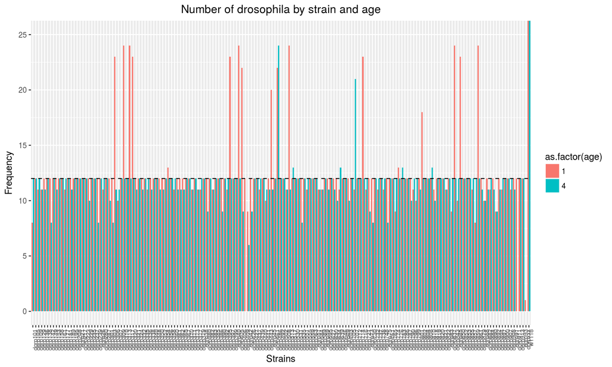

The uncorrect strain, dgrpxxx, seems to concern a 1-week old drosophila. It could be a drosophila lost from one of the actually 167 DGRP strains studied here. It’s not found in the phenotype_data file, so it won’t be an issue later.

Because we expected 12 drosophiles per age and strain at most, the question of duplicates emerged. It can provide information on the most easily maintained lines or on the variation of phenotypic data according to dates of breeding and dissection. A first step was to see the lines that had a larger number of drosophils without duplicates, then to look for real duplicates.

**Experience with same date-age-strain and number of drosophilia over 12**

|  | strain_number | age | date | Freq |
| --- | --- | --- | --- | --- |
| 1113 | dgrp356 | 1 | 260115 | 13 |
| 2155 | dgrp517 | 4 | 40414 | 13 |
| 2526 | dgrp639 | 4 | 40414 | 13 |
| 2713 | dgrp716 | 1 | 20715 | 23 |
| 2995 | dgrp776 | 1 | 20715 | 13 |
| 3032 | dgrp783 | 4 | 70715 | 13 |
| 3273 | dgrp810 | 4 | 70715 | 13 |

**Duplicated strains for age 1**

|  | strain_number | Nb_of_Duplicates |
| --- | --- | --- |
| 29 | dgrp306 | 2 |
| 32 | dgrp310 | 2 |
| 34 | dgrp317 | 2 |
| 35 | dgrp320 | 2 |
| 68 | dgrp397 | 2 |
| 71 | dgrp405 | 2 |
| 72 | dgrp406 | 2 |
| 82 | dgrp45 | 2 |
| 84 | dgrp486 | 2 |
| 88 | dgrp513 | 2 |
| 133 | dgrp802 | 2 |
| 144 | dgrp843 | 2 |
| 146 | dgrp850 | 2 |
| 152 | dgrp861 | 2 |

**Duplicated strains for age 4**

|  | strain_number | Nb_of_Duplicates |
| --- | --- | --- |
| 84 | dgrp486 | 2 |
| 110 | dgrp707 | 2 |

7 experiments had implicated more than 12 drosophiles, and 16 strains had been duplicated, which coincides well with what we can see on the previous graphic.

Caring about the clarity of the document, detail of the duplicate lines, i. e. the dates and number of drosophiles for each manipulation, are not displayed here but have been calculated.

## Collected data

Now that we know what samples we are working on, we will look at the data that has been collected for the study.

```
## Total number of collected data : 147285
```

```
## 34 phenotypes are studied here :
```

```
## Heartrate_Mean
## Heartrate_Median
## Heartrate_StdDev
## Heartrate_StdDevOnMedian
## Heartperiod_Mean
## Heartperiod_Median
## Heartperiod_StdDev
## Heartperiod_StdDevOnMedian
## DiastolicIntervals_Mean
## DiastolicIntervals_Median
## DiastolicIntervals_StdDev
## DiastolicIntervals_StdDevOnMedian
## DI_on_Hp_Mean
## Total_DI_Time
## SystolicIntervals_Mean
## SystolicIntervals_Median
## SystolicIntervals_StdDev
## SystolicIntervals_StdDevOnMedian
## SystolicIntervals_SI_on_Hp_Mean
## Total_SI_Time
## SD_on_Median_Heartperiod
## SI_on_DI_Mean
## DiastolicMeanDiameter
## SystolicMeanDiameter
## FractionalShortening
## Total_DI
## Pcent_Long_DI
## Total_SI
## NormalizedIntervals_Mean
## NormalizedIntervals_Median
## NormalizedIntervals_StdDev
## NormalizedIntervals_StdDevOnMedian
## Pcent_DI_sup3
## Pcent_Long_SI
```

34 phenotypes are collected by used methods. Many of them are probably correlated, which is one of the analysis we will have to do later (or maybe was already done). Here is the graphique of data collected for each age and phenotype.

| Age | Nb_Collected_Individuals |
| --- | --- |
| 1 | 2463 |
| 4 | 2315 |

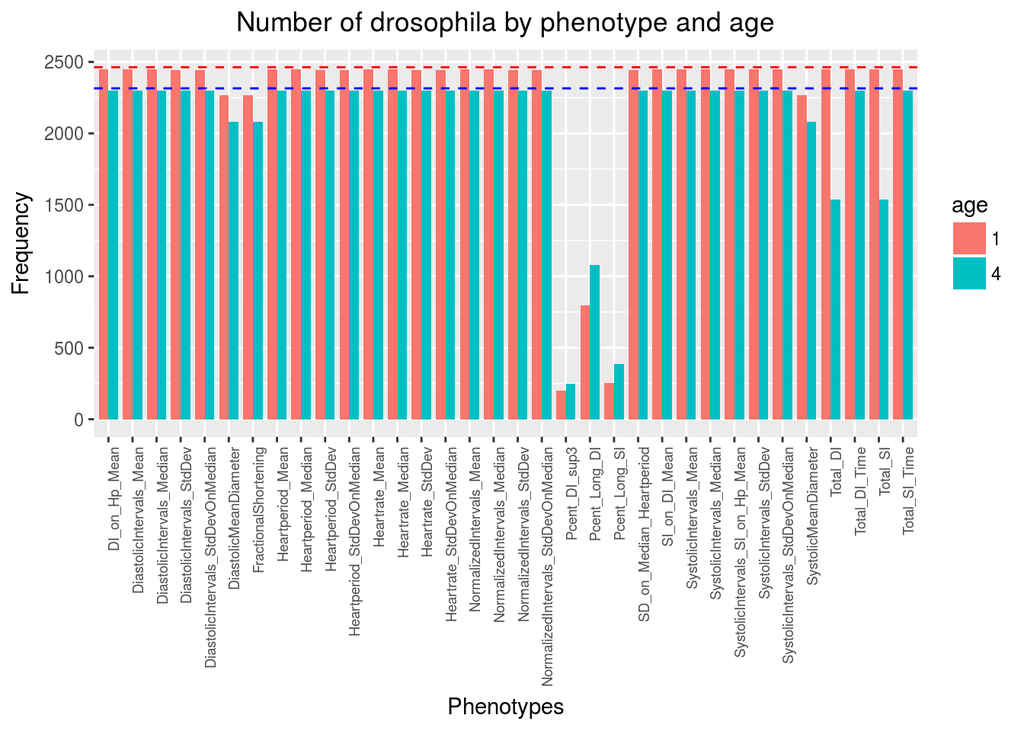

Three phenotypes quite related have a low number of data : DI% , Long DI %, Long SI %. Apparently, the low number of data collected is due to the method and movie. Total_DI and Total_SI have more data but still less than all others phenotypes.

# First approach of phenotypic data

To start exploring phenotypic data, we will take a look at the first phenotype present in the file phenotype_data.csv : HeartRateMean.

## Differences in phenotypic data brought by corrections

The first work was to calculate the phenotypic values with the daily correction. This correction was calculated only for flies one week old. Based on the dates and phenotype names, the daily correction could be applied to almost all 147285 data collected, regardless of age. The data boxplot with the daily correction for age 1 and age 4 gives us an overview of the final result but is not to be taken as such. In an overall way, we don’t know yet if we should take account of this correction because the control wasn’t done in a statistically good way, due to lack of time and hands.

Summary tables of data from the different sources are displayed just below boxplots.

```
## Number of data corrected with daily effect: 146553
```

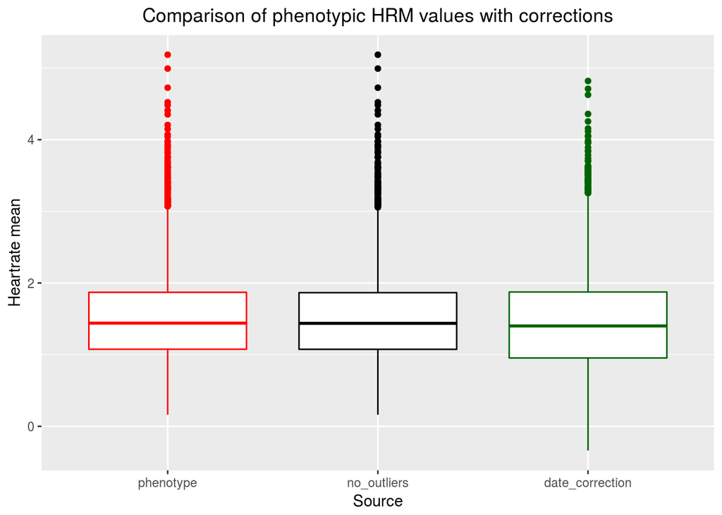

|  | pheno | nooutliers | datecorrection |
| --- | --- | --- | --- |
| Min. | 0.1617476 | 0.1617476 | -0.3371899 |
| 1st Qu. | 1.0760591 | 1.0748872 | 0.9539222 |
| Median | 1.4398823 | 1.4373181 | 1.4006044 |
| Mean | 1.5304591 | 1.5237998 | 1.4540672 |
| 3rd Qu. | 1.8698902 | 1.8652108 | 1.8746276 |
| Max. | 5.1851030 | 5.1851030 | 4.8188758 |

As expected, three boxplots and their values are similar. We will continue only with no corrected values for the next descriptives statistiques.

## Variabily between strains

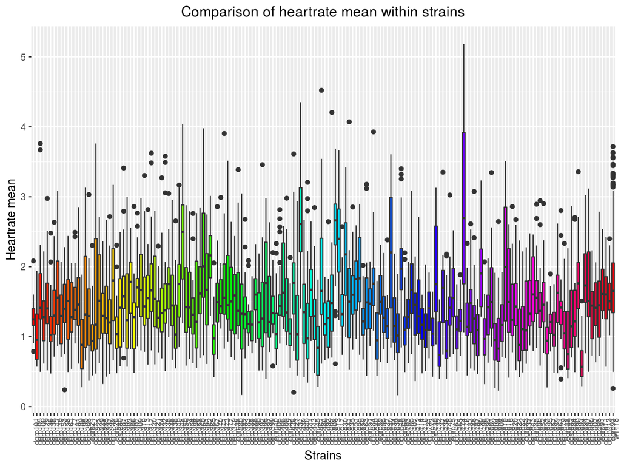

This graphic shows us the variability between all strains for the HeartRate Mean phenotype, which is quite important. Same variations are observed with corrected data. The strain with the more different variability is not the control w1118 but one of the dgrp lines.

## Differences between ages

One of the study’s problems being to get a better understand of cardiac aging mechanism, isogenetic drosophiles were studied at 1 and 4 weeks.

| Age | Nb donnees |
| --- | --- |
| 1 | 2447 |
| 4 | 2297 |

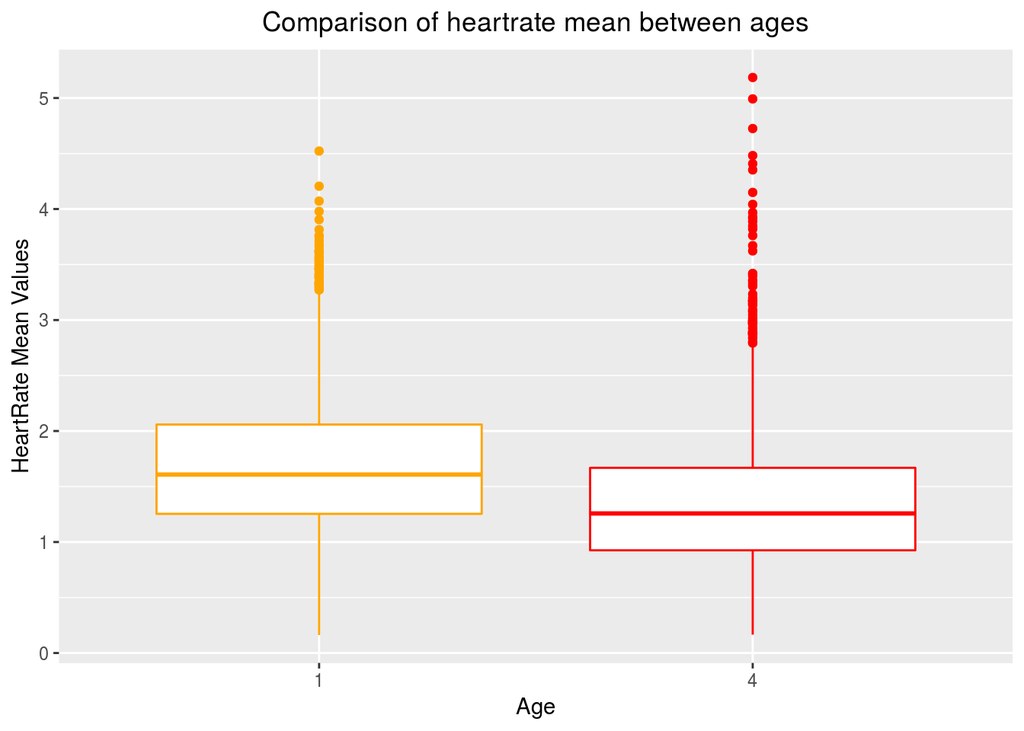

|  | age1 | age4 |
| --- | --- | --- |
| Min. | 0.1617476 | 0.1654544 |
| 1st Qu. | 1.2537770 | 0.9256255 |
| Median | 1.6076884 | 1.2575406 |
| Mean | 1.6938797 | 1.3563667 |
| 3rd Qu. | 2.0585788 | 1.6684126 |
| Max. | 4.5222262 | 5.1851030 |

We notice a general tendency wich is the heartrate mean to get lower with age. It may be verify by a test of Welch after a levene test to know about the homosedacity of our data. A linear study would be a good idea too.

This tendency can be observed in an other way : median of values for HeartRate Mean are plotted in ascending order of the median of 4-week olds.

[output not shown]

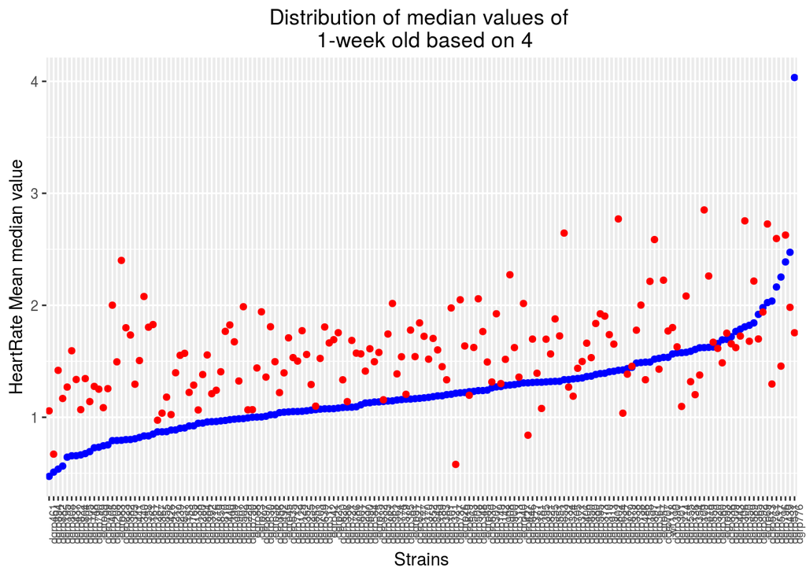